# Final project

TEAM: ARJUN KC(8773456) & Sofiya Sofiya(8902034)

### Telecom Customer Churn Prediction and Analysis

```python
import pandas as pd
import numpy as np
import seaborn as sns
import matplotlib.pyplot as plt
sns.set_style("whitegrid")
```

```python
df_t = pd.read_csv("Telco-Customer-Churn.csv")
```

```python
df_t
```

|  | customerID | gender | SeniorCitizen | Partner | Dependents | tenure | PhoneService | MultipleLines | InternetService | OnlineSecurity | ... | DeviceProtection | TechSupport | StreamingTV | StreamingMovies | Contract | PaperlessBilling | PaymentMethod | MonthlyCharges | TotalCharges | Churn |
| --- | --- | --- | --- | --- | --- | --- | --- | --- | --- | --- | --- | --- | --- | --- | --- | --- | --- | --- | --- | --- | --- |
| 0 | 7590-VHVEG | Female | 0 | Yes | No | 1 | No | No phone service | DSL | No | ... | No | No | No | No | Month-to-month | Yes | Electronic check | 29.85 | 29.85 | No |
| 1 | 5575-GNVDE | Male | 0 | No | No | 34 | Yes | No | DSL | Yes | ... | Yes | No | No | No | One year | No | Mailed check | 56.95 | 1889.5 | No |
| 2 | 3668-QPYBK | Male | 0 | No | No | 2 | Yes | No | DSL | Yes | ... | No | No | No | No | Month-to-month | Yes | Mailed check | 53.85 | 108.15 | Yes |
| 3 | 7795-CFOCW | Male | 0 | No | No | 45 | No | No phone service | DSL | Yes | ... | Yes | Yes | No | No | One year | No | Bank transfer (automatic) | 42.30 | 1840.75 | No |
| 4 | 9237-HQITU | Female | 0 | No | No | 2 | Yes | No | Fiber optic | No | ... | No | No | No | No | Month-to-month | Yes | Electronic check | 70.70 | 151.65 | Yes |
| ... | ... | ... | ... | ... | ... | ... | ... | ... | ... | ... | ... | ... | ... | ... | ... | ... | ... | ... | ... | ... | ... |
| 7038 | 6840-RESVB | Male | 0 | Yes | Yes | 24 | Yes | Yes | DSL | Yes | ... | Yes | Yes | Yes | Yes | One year | Yes | Mailed check | 84.80 | 1990.5 | No |
| 7039 | 2234-XADUH | Female | 0 | Yes | Yes | 72 | Yes | Yes | Fiber optic | No | ... | Yes | No | Yes | Yes | One year | Yes | Credit card (automatic) | 103.20 | 7362.9 | No |
| 7040 | 4801-JZAZL | Female | 0 | Yes | Yes | 11 | No | No phone service | DSL | Yes | ... | No | No | No | No | Month-to-month | Yes | Electronic check | 29.60 | 346.45 | No |
| 7041 | 8361-LTMKD | Male | 1 | Yes | No | 4 | Yes | Yes | Fiber optic | No | ... | No | No | No | No | Month-to-month | Yes | Mailed check | 74.40 | 306.6 | Yes |
| 7042 | 3186-AJIEK | Male | 0 | No | No | 66 | Yes | No | Fiber optic | Yes | ... | Yes | Yes | Yes | Yes | Two year | Yes | Bank transfer (automatic) | 105.65 | 6844.5 | No |

7043 rows × 21 columns

```python
df_t.shape
```

```
(7043, 21)
```

```python
df_t.columns
```

```
Index(['customerID', 'gender', 'SeniorCitizen', 'Partner', 'Dependents',
       'tenure', 'PhoneService', 'MultipleLines', 'InternetService',
       'OnlineSecurity', 'OnlineBackup', 'DeviceProtection', 'TechSupport',
       'StreamingTV', 'StreamingMovies', 'Contract', 'PaperlessBilling',
       'PaymentMethod', 'MonthlyCharges', 'TotalCharges', 'Churn'],
      dtype='object')
```

```python
df_t.isnull().sum()  #there is no missing values in our dataset but there is numeric column which is in object datatype
```

```
customerID          0
gender              0
SeniorCitizen       0
Partner             0
Dependents          0
tenure              0
PhoneService        0
MultipleLines       0
InternetService     0
OnlineSecurity      0
OnlineBackup        0
DeviceProtection    0
TechSupport         0
StreamingTV         0
StreamingMovies     0
Contract            0
PaperlessBilling    0
PaymentMethod       0
MonthlyCharges      0
TotalCharges        0
Churn               0
dtype: int64
```

```python
df_t.info()  #we have many object in dataset
```

```
<class 'pandas.core.frame.DataFrame'>
RangeIndex: 7043 entries, 0 to 7042
Data columns (total 21 columns):
 #   Column            Non-Null Count  Dtype
---  ------            --------------  -----
 0   customerID        7043 non-null   object
 1   gender            7043 non-null   object
 2   SeniorCitizen     7043 non-null   int64
 3   Partner           7043 non-null   object
 4   Dependents        7043 non-null   object
 5   tenure            7043 non-null   int64
 6   PhoneService      7043 non-null   object
 7   MultipleLines     7043 non-null   object
 8   InternetService   7043 non-null   object
 9   OnlineSecurity    7043 non-null   object
 10  OnlineBackup      7043 non-null   object
 11  DeviceProtection  7043 non-null   object
 12  TechSupport       7043 non-null   object
 13  StreamingTV       7043 non-null   object
 14  StreamingMovies   7043 non-null   object
 15  Contract          7043 non-null   object
 16  PaperlessBilling  7043 non-null   object
 17  PaymentMethod     7043 non-null   object
 18  MonthlyCharges    7043 non-null   float64
 19  TotalCharges      7043 non-null   object
 20  Churn             7043 non-null   object
dtypes: float64(1), int64(2), object(18)
memory usage: 1.1+ MB
```

Removing the Customer ID columns as it doesnot give significanet meaning

```python
df_t.drop(columns=["customerID"],inplace=True)
```

```python
df_t # we droped the customerID columns
```

|  | gender | SeniorCitizen | Partner | Dependents | tenure | PhoneService | MultipleLines | InternetService | OnlineSecurity | OnlineBackup | DeviceProtection | TechSupport | StreamingTV | StreamingMovies | Contract | PaperlessBilling | PaymentMethod | MonthlyCharges | TotalCharges | Churn |
| --- | --- | --- | --- | --- | --- | --- | --- | --- | --- | --- | --- | --- | --- | --- | --- | --- | --- | --- | --- | --- |
| 0 | Female | 0 | Yes | No | 1 | No | No phone service | DSL | No | Yes | No | No | No | No | Month-to-month | Yes | Electronic check | 29.85 | 29.85 | No |
| 1 | Male | 0 | No | No | 34 | Yes | No | DSL | Yes | No | Yes | No | No | No | One year | No | Mailed check | 56.95 | 1889.5 | No |
| 2 | Male | 0 | No | No | 2 | Yes | No | DSL | Yes | Yes | No | No | No | No | Month-to-month | Yes | Mailed check | 53.85 | 108.15 | Yes |
| 3 | Male | 0 | No | No | 45 | No | No phone service | DSL | Yes | No | Yes | Yes | No | No | One year | No | Bank transfer (automatic) | 42.30 | 1840.75 | No |
| 4 | Female | 0 | No | No | 2 | Yes | No | Fiber optic | No | No | No | No | No | No | Month-to-month | Yes | Electronic check | 70.70 | 151.65 | Yes |
| ... | ... | ... | ... | ... | ... | ... | ... | ... | ... | ... | ... | ... | ... | ... | ... | ... | ... | ... | ... | ... |
| 7038 | Male | 0 | Yes | Yes | 24 | Yes | Yes | DSL | Yes | No | Yes | Yes | Yes | Yes | One year | Yes | Mailed check | 84.80 | 1990.5 | No |
| 7039 | Female | 0 | Yes | Yes | 72 | Yes | Yes | Fiber optic | No | Yes | Yes | No | Yes | Yes | One year | Yes | Credit card (automatic) | 103.20 | 7362.9 | No |
| 7040 | Female | 0 | Yes | Yes | 11 | No | No phone service | DSL | Yes | No | No | No | No | No | Month-to-month | Yes | Electronic check | 29.60 | 346.45 | No |
| 7041 | Male | 1 | Yes | No | 4 | Yes | Yes | Fiber optic | No | No | No | No | No | No | Month-to-month | Yes | Mailed check | 74.40 | 306.6 | Yes |
| 7042 | Male | 0 | No | No | 66 | Yes | No | Fiber optic | Yes | No | Yes | Yes | Yes | Yes | Two year | Yes | Bank transfer (automatic) | 105.65 | 6844.5 | No |

7043 rows × 20 columns

```python
df_t["PaymentMethod"].value_counts()
```

```
Electronic check             2365
Mailed check                 1612
Bank transfer (automatic)    1544
Credit card (automatic)      1522
Name: PaymentMethod, dtype: int64
```

```python
df_t["MultipleLines"].value_counts()
```

```
No                  3390
Yes                 2971
No phone service     682
Name: MultipleLines, dtype: int64
```

```python
df_t["InternetService"].value_counts()
```

```
Fiber optic    3096
DSL            2421
No             1526
Name: InternetService, dtype: int64
```

as our dataset has some ordinal and nominal columns so we perfer to use all one hot encoding rather than label enconder

```python
df_t.head()
```

|  | gender | SeniorCitizen | Partner | Dependents | tenure | PhoneService | MultipleLines | InternetService | OnlineSecurity | OnlineBackup | DeviceProtection | TechSupport | StreamingTV | StreamingMovies | Contract | PaperlessBilling | PaymentMethod | MonthlyCharges | TotalCharges | Churn |
| --- | --- | --- | --- | --- | --- | --- | --- | --- | --- | --- | --- | --- | --- | --- | --- | --- | --- | --- | --- | --- |
| 0 | Female | 0 | Yes | No | 1 | No | No phone service | DSL | No | Yes | No | No | No | No | Month-to-month | Yes | Electronic check | 29.85 | 29.85 | No |
| 1 | Male | 0 | No | No | 34 | Yes | No | DSL | Yes | No | Yes | No | No | No | One year | No | Mailed check | 56.95 | 1889.5 | No |
| 2 | Male | 0 | No | No | 2 | Yes | No | DSL | Yes | Yes | No | No | No | No | Month-to-month | Yes | Mailed check | 53.85 | 108.15 | Yes |
| 3 | Male | 0 | No | No | 45 | No | No phone service | DSL | Yes | No | Yes | Yes | No | No | One year | No | Bank transfer (automatic) | 42.30 | 1840.75 | No |
| 4 | Female | 0 | No | No | 2 | Yes | No | Fiber optic | No | No | No | No | No | No | Month-to-month | Yes | Electronic check | 70.70 | 151.65 | Yes |

```python
df_t.describe() #as we can we cant see Totalcharge column as in not shown here as it is in object form
```

|  | SeniorCitizen | tenure | MonthlyCharges |
| --- | --- | --- | --- |
| count | 7043.000000 | 7043.000000 | 7043.000000 |
| mean | 0.162147 | 32.371149 | 64.761692 |
| std | 0.368612 | 24.559481 | 30.090047 |
| min | 0.000000 | 0.000000 | 18.250000 |
| 25% | 0.000000 | 9.000000 | 35.500000 |
| 50% | 0.000000 | 29.000000 | 70.350000 |
| 75% | 0.000000 | 55.000000 | 89.850000 |
| max | 1.000000 | 72.000000 | 118.750000 |

Dealing with outliers

```python
df_t["TotalCharges"].info()
```

```
<class 'pandas.core.series.Series'>
RangeIndex: 7043 entries, 0 to 7042
Series name: TotalCharges
Non-Null Count  Dtype
--------------  -----
7043 non-null   object
dtypes: object(1)
memory usage: 55.2+ KB
```

Now converting that object of Totalcharge columns to numeric

```python
df_t["TotalCharges"] = pd.to_numeric(df_t["TotalCharges"],errors="coerce")
```

```python
df_t["TotalCharges"].info
```

```
<bound method Series.info of 0         29.85
1       1889.50
2        108.15
3       1840.75
4        151.65
         ...
7038    1990.50
7039    7362.90
7040     346.45
7041     306.60
7042    6844.50
Name: TotalCharges, Length: 7043, dtype: float64>
```

```python
df_t.isnull().sum()  # we can see after converting df_t["Totalcharge"] column to from object to numeric we got to know that there is 11missing value
```

```
gender               0
SeniorCitizen        0
Partner              0
Dependents           0
tenure               0
PhoneService         0
MultipleLines        0
InternetService      0
OnlineSecurity       0
OnlineBackup         0
DeviceProtection     0
TechSupport          0
StreamingTV          0
StreamingMovies      0
Contract             0
PaperlessBilling     0
PaymentMethod        0
MonthlyCharges       0
TotalCharges        11
Churn                0
dtype: int64
```

Now replacing the missing values in Totalcharge columns

```python
repl_miss = df_t["TotalCharges"].mean()
```

```python
df_t.fillna(repl_miss,inplace= True)
```

```python
df_t.isnull().sum()
```

```
gender              0
SeniorCitizen       0
Partner             0
Dependents          0
tenure              0
PhoneService        0
MultipleLines       0
InternetService     0
OnlineSecurity      0
OnlineBackup        0
DeviceProtection    0
TechSupport         0
StreamingTV         0
StreamingMovies     0
Contract            0
PaperlessBilling    0
PaymentMethod       0
MonthlyCharges      0
TotalCharges        0
Churn               0
dtype: int64
```

```python
col = ["SeniorCitizen","tenure","MonthlyCharges","TotalCharges"]
```

```python
df_t[col].describe()
```

|  | SeniorCitizen | tenure | MonthlyCharges | TotalCharges |
| --- | --- | --- | --- | --- |
| count | 7043.000000 | 7043.000000 | 7043.000000 | 7043.000000 |
| mean | 0.162147 | 32.371149 | 64.761692 | 2283.300441 |
| std | 0.368612 | 24.559481 | 30.090047 | 2265.000258 |
| min | 0.000000 | 0.000000 | 18.250000 | 18.800000 |
| 25% | 0.000000 | 9.000000 | 35.500000 | 402.225000 |
| 50% | 0.000000 | 29.000000 | 70.350000 | 1400.550000 |
| 75% | 0.000000 | 55.000000 | 89.850000 | 3786.600000 |
| max | 1.000000 | 72.000000 | 118.750000 | 8684.800000 |

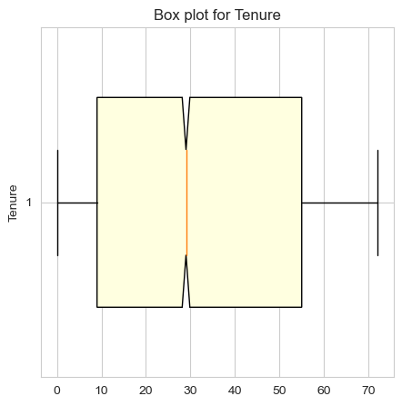

```python
plt.figure(figsize=(5,5))
plt.boxplot(df_t["tenure"],vert=False,widths=0.6,notch =True,patch_artist=True,boxprops=dict(facecolor="lightyellow"))
plt.title("Box plot for Tenure")
plt.ylabel("Tenure")
plt.show()
```

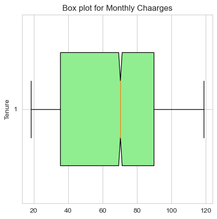

```python
plt.figure(figsize=(5,5))
plt.boxplot(df_t["MonthlyCharges"],vert=False,widths=0.6,notch =True,patch_artist=True,boxprops=dict(facecolor="lightgreen"))
plt.title("Box plot for Monthly Chaarges")
plt.ylabel("Tenure")
plt.show()
```

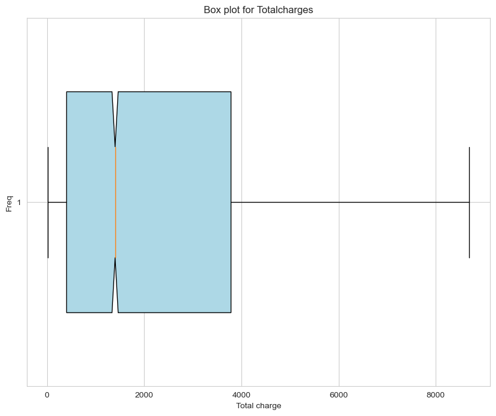

```python
plt.figure(figsize=(10,8))
plt.boxplot(df_t["TotalCharges"],vert=False,widths=0.6,notch =True,patch_artist=True,boxprops=dict(facecolor="lightblue"))
plt.title("Box plot for Totalcharges")
plt.xlabel("Total charge")
plt.ylabel("Freq")
plt.show()
```

Dealing the outlier using IQR(Inter-Quartile-Range for TotalCharge columns)

```python
q1= df_t["TotalCharges"].quantile(0.25)
q3 = df_t["TotalCharges"].quantile(0.75)
IQR = q3-q1
print(q1)
print(q3)
print(IQR)
```

```
402.225
3786.6
3384.375
```

```python
lwr_bnd = q1-1.5*IQR
uppr_bnd =q3+1.5*IQR
print(lwr_bnd)
print(uppr_bnd)
```

```
-4674.3375
8863.1625
```

```python
def totl_outlr(x):
    if x>uppr_bnd:
        return uppr_bnd
    elif x<lwr_bnd:
        return lwr_bnd
    else:
        return x
```

```python
df_t["TotalCharges"]= df_t["TotalCharges"].apply(totl_outlr)
```

[figure not shown]

```python
plt.figure(figsize=(10,8))
plt.boxplot(df_t["TotalCharges"],vert=False,widths=0.6,notch =True,patch_artist=True,boxprops=dict(facecolor="lightblue"))
plt.title("Box plot for Tenure")
plt.xlabel("Total charge")
plt.ylabel("Freq")
plt.show()
```

```python
df_t[col].describe()
```

|  | SeniorCitizen | tenure | MonthlyCharges | TotalCharges |
| --- | --- | --- | --- | --- |
| count | 7043.000000 | 7043.000000 | 7043.000000 | 7043.000000 |
| mean | 0.162147 | 32.371149 | 64.761692 | 2283.300441 |
| std | 0.368612 | 24.559481 | 30.090047 | 2265.000258 |
| min | 0.000000 | 0.000000 | 18.250000 | 18.800000 |
| 25% | 0.000000 | 9.000000 | 35.500000 | 402.225000 |
| 50% | 0.000000 | 29.000000 | 70.350000 | 1400.550000 |
| 75% | 0.000000 | 55.000000 | 89.850000 | 3786.600000 |
| max | 1.000000 | 72.000000 | 118.750000 | 8684.800000 |

```python
df_t.isnull().sum()  #as our data have no missing value so no need to use imputation method like mean, median and mode
```

```
gender              0
SeniorCitizen       0
Partner             0
Dependents          0
tenure              0
PhoneService        0
MultipleLines       0
InternetService     0
OnlineSecurity      0
OnlineBackup        0
DeviceProtection    0
TechSupport         0
StreamingTV         0
StreamingMovies     0
Contract            0
PaperlessBilling    0
PaymentMethod       0
MonthlyCharges      0
TotalCharges        0
Churn               0
dtype: int64
```

Doing the EDA

```python
df_t.columns
```

```
Index(['gender', 'SeniorCitizen', 'Partner', 'Dependents', 'tenure',
       'PhoneService', 'MultipleLines', 'InternetService', 'OnlineSecurity',
       'OnlineBackup', 'DeviceProtection', 'TechSupport', 'StreamingTV',
       'StreamingMovies', 'Contract', 'PaperlessBilling', 'PaymentMethod',
       'MonthlyCharges', 'TotalCharges', 'Churn'],
      dtype='object')
```

```python
snr_ctz = df_t["SeniorCitizen"].value_counts()
print(snr_ctz)
```

```
0    5901
1    1142
Name: SeniorCitizen, dtype: int64
```

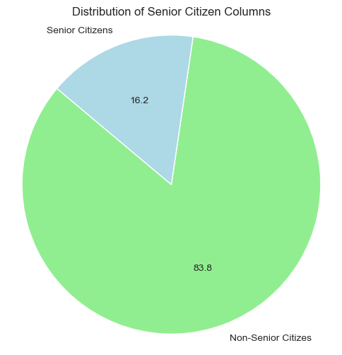

```python
plt.figure(figsize=(6,6))
plt.pie(snr_ctz,labels= ["Non-Senior Citizes","Senior Citizens"],autopct='%1.1f',startangle =140,colors=["lightgreen","lightblue"])
plt.title("Distribution of Senior Citizen Columns")
plt.axis("Equal")
plt.show()
```

Distribution of data by Churn

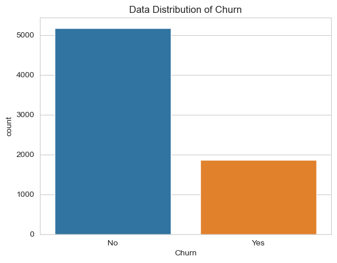

```python
sns.countplot(x=df_t["Churn"],data=df_t)
plt.title("Data Distribution of Churn")
plt.show()
```

Distribution of data by Gender and Churn

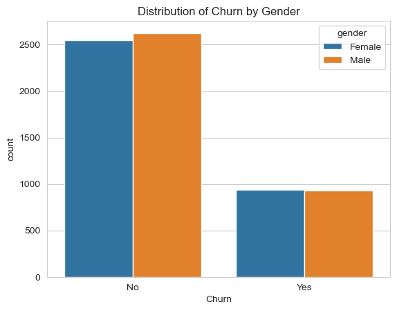

```python
sns.countplot(x=df_t["Churn"],hue=df_t["gender"],data=df_t)
plt.title("Distribution of Churn by Gender")
plt.show()
```

Distribution of Data by Internet Service and Churn

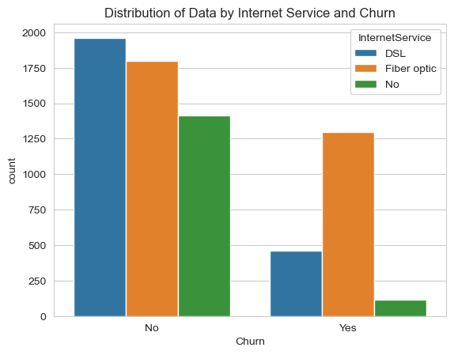

```python
sns.countplot(x=df_t["Churn"],hue=df_t["InternetService"],data=df_t)
plt.title("Distribution of Data by Internet Service and Churn")
plt.show()
```

Data Distribution for Tenure

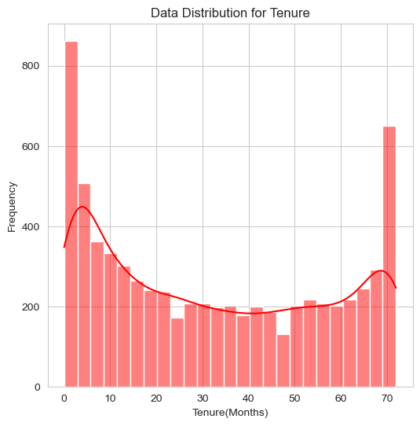

```python
plt.figure(figsize=(6,6))
sns.histplot(data = df_t,x=df_t["tenure"],bins=25,kde=True,color="red")
plt.title("Data Distribution for Tenure")
plt.xlabel("Tenure(Months)")
plt.ylabel("Frequency")
plt.show()
```

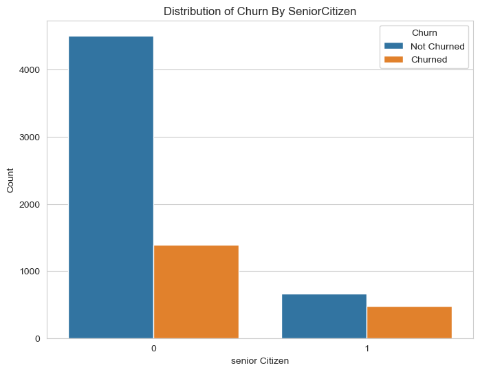

```python
plt.figure(figsize=(8,6))
sns.countplot(x=df_t["SeniorCitizen"],hue=df_t["Churn"],data=df_t)
plt.title("Distribution of Churn By SeniorCitizen")
plt.xlabel("senior Citizen")
plt.ylabel("Count")
plt.legend(title="Churn",loc="upper right",labels=["Not Churned","Churned"])
plt.xticks([0,1])
plt.show()
```

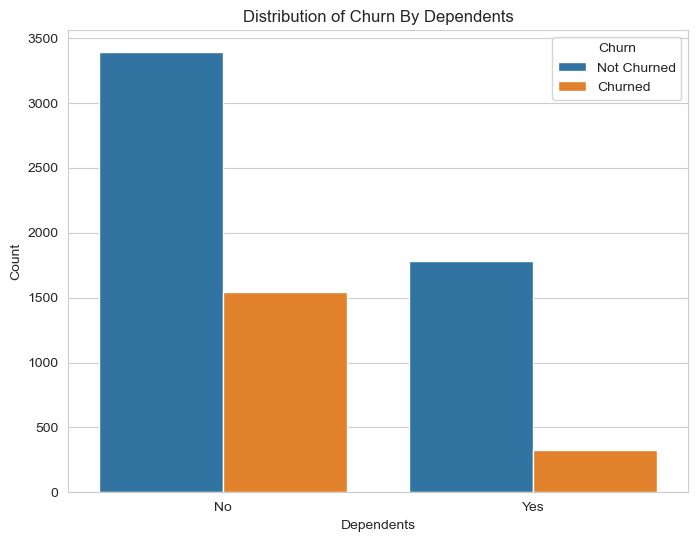

```python
plt.figure(figsize=(8,6))
sns.countplot(x=df_t["Dependents"],hue=df_t["Churn"],data=df_t)
plt.title("Distribution of Churn By Dependents")
plt.xlabel("Dependents")
plt.ylabel("Count")
plt.legend(title="Churn",loc="upper right",labels=["Not Churned","Churned"])
plt.xticks([0,1])
plt.show()
```

Data Distribution by Contract

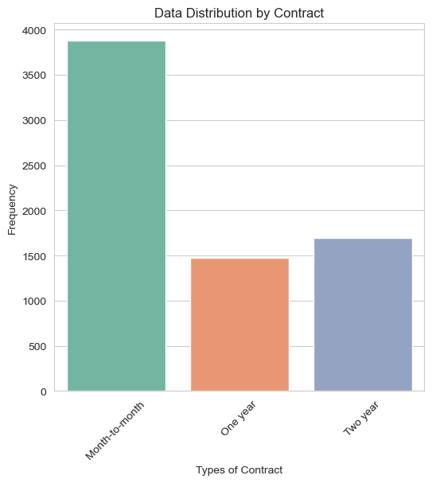

```python
plt.figure(figsize=(6,6))
sns.countplot(data=df_t,x=df_t["Contract"],palette="Set2")
plt.title("Data Distribution by Contract")
plt.xlabel("Types of Contract")
plt.ylabel("Frequency")
plt.xticks(rotation=45)
plt.show()
```

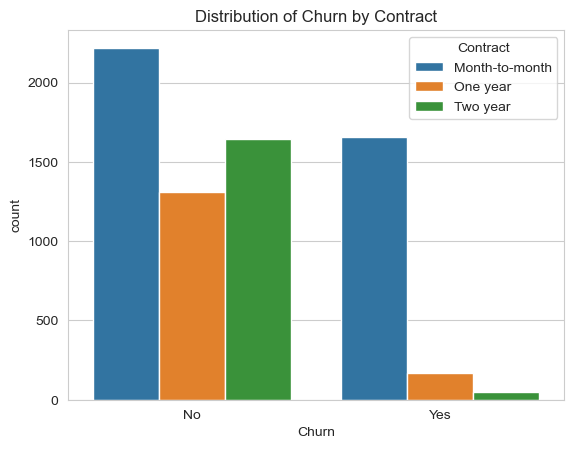

```python
sns.countplot(x=df_t["Churn"],hue=df_t["Contract"],data=df_t)
plt.title("Distribution of Churn by Contract")
plt.xlabel("Churn")
plt.ylabel("count")
plt.legend(title="Contract",loc="upper right")
plt.show()
```

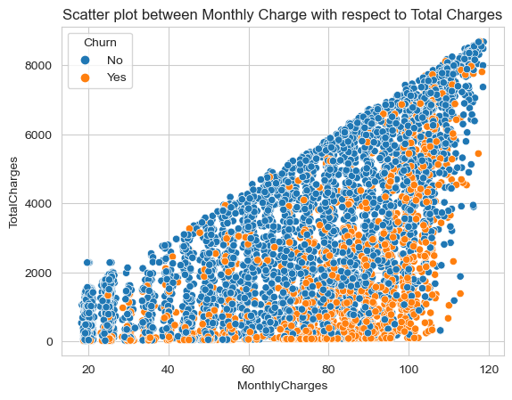

```python
sns.scatterplot(x= df_t["MonthlyCharges"],y=df_t["TotalCharges"],hue=df_t["Churn"],data=df_t)
plt.title("Scatter plot between Monthly Charge with respect to Total Charges")
plt.show()
```

Defining the Correlation

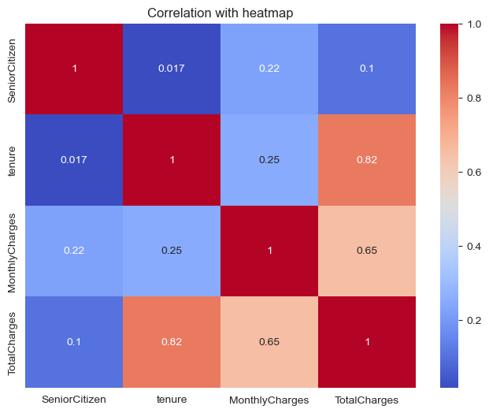

```python
plt.figure(figsize=(8,6))
sns.heatmap(df_t.corr(),annot=True,cmap="coolwarm")
plt.title("Correlation with heatmap")
plt.show()
```

From heatmap we can see that tenure has positive relation with total charges

As our dataset are more categorical so converting them to numericals and we perform the one hot encoding as our dataset most of them is no ordinal

```python
from sklearn.preprocessing import LabelEncoder,OneHotEncoder
```

```python
lab =LabelEncoder()
```

```python
df_t["Churn"] = lab.fit_transform(df_t["Churn"])
df_t["gender"] = lab.fit_transform(df_t["gender"])
df_t["Partner"] = lab.fit_transform(df_t["Partner"])
```

```python
df_t = pd.get_dummies(df_t,columns=[ 'Dependents','PhoneService', 'MultipleLines', 'InternetService', 'OnlineSecurity',
       'OnlineBackup', 'DeviceProtection', 'TechSupport', 'StreamingTV',
       'StreamingMovies', 'Contract', 'PaperlessBilling', 'PaymentMethod',])
```

```python
df_t.head()
```

|  | gender | SeniorCitizen | Partner | tenure | MonthlyCharges | TotalCharges | Churn | Dependents_No | Dependents_Yes | PhoneService_No | ... | StreamingMovies_Yes | Contract_Month-to-month | Contract_One year | Contract_Two year | PaperlessBilling_No | PaperlessBilling_Yes | PaymentMethod_Bank transfer (automatic) | PaymentMethod_Credit card (automatic) | PaymentMethod_Electronic check | PaymentMethod_Mailed check |
| --- | --- | --- | --- | --- | --- | --- | --- | --- | --- | --- | --- | --- | --- | --- | --- | --- | --- | --- | --- | --- | --- |
| 0 | 0 | 0 | 1 | 1 | 29.85 | 29.85 | 0 | 1 | 0 | 1 | ... | 0 | 1 | 0 | 0 | 0 | 1 | 0 | 0 | 1 | 0 |
| 1 | 1 | 0 | 0 | 34 | 56.95 | 1889.50 | 0 | 1 | 0 | 0 | ... | 0 | 0 | 1 | 0 | 1 | 0 | 0 | 0 | 0 | 1 |
| 2 | 1 | 0 | 0 | 2 | 53.85 | 108.15 | 1 | 1 | 0 | 0 | ... | 0 | 1 | 0 | 0 | 0 | 1 | 0 | 0 | 0 | 1 |
| 3 | 1 | 0 | 0 | 45 | 42.30 | 1840.75 | 0 | 1 | 0 | 1 | ... | 0 | 0 | 1 | 0 | 1 | 0 | 1 | 0 | 0 | 0 |
| 4 | 0 | 0 | 0 | 2 | 70.70 | 151.65 | 1 | 1 | 0 | 0 | ... | 0 | 1 | 0 | 0 | 0 | 1 | 0 | 0 | 1 | 0 |

5 rows × 44 columns

```python
df_t["Churn"].value_counts()
```

```
0    5174
1    1869
Name: Churn, dtype: int64
```

Now spliting the data into dependent and independent variable

```python
X = df_t.drop(columns=["Churn"])
```

```python
y = df_t["Churn"]
```

Now spliting data into training and testing sets

```python
from sklearn.model_selection import train_test_split
```

```python
X_train,X_test,y_train,y_test =train_test_split(X,y,test_size=0.20,random_state=42)
```

Now doing feautre Scaling

```python
from sklearn.preprocessing import StandardScaler
```

```python
scal = StandardScaler()
```

```python
X_train_scal = scal.fit_transform(X_train)
print(X_train_scal)
```

```
[[-1.02516569 -0.4377492  -0.96957859 ... -0.52765585 -0.70964983
   1.84247002]
 [-1.02516569 -0.4377492  -0.96957859 ... -0.52765585 -0.70964983
  -0.54274967]
 [ 0.97545208 -0.4377492   1.03137591 ... -0.52765585  1.40914569
  -0.54274967]
 ...
 [ 0.97545208 -0.4377492   1.03137591 ... -0.52765585  1.40914569
  -0.54274967]
 [ 0.97545208  2.28441306 -0.96957859 ... -0.52765585  1.40914569
  -0.54274967]
 [ 0.97545208 -0.4377492  -0.96957859 ...  1.89517467 -0.70964983
  -0.54274967]]
```

```python
X_test_scal = scal.transform(X_test)
print(X_test_scal)
```

```
[[-1.02516569 -0.4377492   1.03137591 ... -0.52765585  1.40914569
  -0.54274967]
 [ 0.97545208 -0.4377492  -0.96957859 ... -0.52765585 -0.70964983
  -0.54274967]
 [-1.02516569 -0.4377492   1.03137591 ... -0.52765585 -0.70964983
   1.84247002]
 ...
 [ 0.97545208 -0.4377492   1.03137591 ... -0.52765585 -0.70964983
  -0.54274967]
 [-1.02516569 -0.4377492   1.03137591 ...  1.89517467 -0.70964983
  -0.54274967]
 [ 0.97545208 -0.4377492  -0.96957859 ... -0.52765585 -0.70964983
   1.84247002]]
```

Now using different Model for the prediction

```python
from sklearn.metrics import accuracy_score,confusion_matrix,classification_report
from sklearn.ensemble import RandomForestClassifier
from sklearn.linear_model import LogisticRegression
from sklearn.svm import SVC
from sklearn.naive_bayes import GaussianNB
```

### @ Random Forest

Defining the model

```python
rf_cls= RandomForestClassifier(random_state=42)
```

now train the classifier on the training data set

```python
rf_cls.fit(X_train_scal,y_train)
```

```
RandomForestClassifier(random_state=42)
```

Now making prediction on the test data

```python
y_prd_rf = rf_cls.predict(X_test_scal)
```

Now evaluating the performance of models

```python
acry_rf= accuracy_score(y_test,y_prd_rf)
```

```python
conf_mat = confusion_matrix(y_test,y_prd_rf)
```

```python
clas_rpt = classification_report(y_test,y_prd_rf)
```

```python
print("Results of Random Forest Metrics are:")
print(f'Accuracy of Random forest:{acry_rf:.2f}')
print("Confusion Matrix of Random Forest Classifier:\n",conf_mat)
print("\n Classification of Random Forest Classifier:\n",clas_rpt)
```

```
Results of Random Forest Metrics are:
Accuracy of Random forest:0.80
Confusion Matrix of Random Forest Classifier:
 [[946  90]
 [198 175]]

 Classification of Random Forest Classifier:
               precision    recall  f1-score   support

           0       0.83      0.91      0.87      1036
           1       0.66      0.47      0.55       373

    accuracy                           0.80      1409
   macro avg       0.74      0.69      0.71      1409
weighted avg       0.78      0.80      0.78      1409
```

### As our Data is imbalance so we preform Oversampling using SMOTEENN

```python
from imblearn.combine import SMOTEENN
```

```python
smt = SMOTEENN()
```

```python
X_resampl,y_resampl =smt.fit_resample(X_train_scal,y_train)
Xr_train,Xr_test,yr_train,yr_test =train_test_split(X_resampl,y_resampl,test_size=0.20,random_state=42)
```

```python
rf_cls_sm= RandomForestClassifier(random_state=42)
rf_cls_sm.fit(Xr_train,yr_train)
```

```
RandomForestClassifier(random_state=42)
```

```python
y_prd_rf_sm = rf_cls_sm.predict(Xr_test)
acry_rf_sm = accuracy_score(yr_test,y_prd_rf_sm)
conf_mat_rf_sm = confusion_matrix(yr_test,y_prd_rf_sm)
clas_rpt_rf_sm = classification_report(yr_test,y_prd_rf_sm)
```

```python
print("Results of Random Classifiers Metrics after over sampling are:")
print(f'Accuracy :{acry_rf_sm:.2f}')
print("Confusion Matrix :\n",conf_mat_rf_sm)
print("\n Classification of Report:\n",clas_rpt_rf_sm)
```

```
Results of Random Classifiers Metrics after over sampling are:
Accuracy :0.96
Confusion Matrix :
 [[432  24]
 [ 14 528]]

 Classification of Report:
               precision    recall  f1-score   support

           0       0.97      0.95      0.96       456
           1       0.96      0.97      0.97       542

    accuracy                           0.96       998
   macro avg       0.96      0.96      0.96       998
weighted avg       0.96      0.96      0.96       998
```

```python
ttl_cus = len(y_test)
```

```python
churn_cus = sum(y_prd_rf)
```

```python
churn_ratio = churn_cus/ttl_cus
```

```python
print("Total Customer:\n",ttl_cus)
print("Churned customer:\n",churn_cus)
print("Churn ratio:\n",churn_ratio)
```

```
Total Customer:
 1409
Churned customer:
 265
Churn ratio:
 0.1880766501064585
```

### @ Logistic Regression

```python
log_rg = LogisticRegression()
```

```python
log_rg.fit(X_train_scal,y_train)
```

```
LogisticRegression()
```

```python
y_prd_log = log_rg.predict(X_test_scal)
```

```python
acry_log = accuracy_score(y_test,y_prd_log)
```

```python
conf_mat_log = confusion_matrix(y_test,y_prd_log)
clas_rpt_log = classification_report(y_test,y_prd_log)
```

```python
print("Results of Logistice Regression Metrics are:")
print(f'Accuracy of Random forest:{acry_log:.2f}')
print("Confusion Matrix of Random Forest Classifier:\n",conf_mat_log)
print("\n Classification of Random Forest Classifier:\n",clas_rpt_log)
```

```
Results of Logistice Regression Metrics are:
Accuracy of Random forest:0.82
Confusion Matrix of Random Forest Classifier:
 [[934 102]
 [151 222]]

 Classification of Random Forest Classifier:
               precision    recall  f1-score   support

           0       0.86      0.90      0.88      1036
           1       0.69      0.60      0.64       373

    accuracy                           0.82      1409
   macro avg       0.77      0.75      0.76      1409
weighted avg       0.81      0.82      0.82      1409
```

### As our Data is imbalance so we preform Oversampling using SMOTEENN

```python
from imblearn.combine import SMOTEENN
```

```python
smt = SMOTEENN()
```

```python
X_resampl,y_resampl =smt.fit_resample(X_train_scal,y_train)
```

```python
Xr_train,Xr_test,yr_train,yr_test =train_test_split(X_resampl,y_resampl,test_size=0.20,random_state=42)
```

```python
log_rg_sm = LogisticRegression()
```

```python
log_rg_sm.fit(Xr_train,yr_train)
```

```
LogisticRegression()
```

```python
y_prd_log_sm = log_rg_sm.predict(Xr_test)
```

```python
acry_log_sm = accuracy_score(yr_test,y_prd_log_sm)
```

```python
conf_mat_log_sm = confusion_matrix(yr_test,y_prd_log_sm)
clas_rpt_log_sm = classification_report(yr_test,y_prd_log_sm)
```

```python
print("Results of Logistice Regression Metrics after over sampling are:")
print(f'Accuracy :{acry_log_sm:.2f}')
print("Confusion Matrix :\n",conf_mat_log_sm)
print("\n Classification of Report:\n",clas_rpt_log_sm)
```

```
Results of Logistice Regression Metrics after over sampling are:
Accuracy :0.92
Confusion Matrix :
 [[415  42]
 [ 36 514]]

 Classification of Report:
               precision    recall  f1-score   support

           0       0.92      0.91      0.91       457
           1       0.92      0.93      0.93       550

    accuracy                           0.92      1007
   macro avg       0.92      0.92      0.92      1007
weighted avg       0.92      0.92      0.92      1007
```

### @ SVM

```python
svm_mdl = SVC(kernel="linear")
```

```python
svm_mdl.fit(X_train_scal,y_train)
```

```
SVC(kernel='linear')
```

```python
y_prd_svm = svm_mdl.predict(X_test_scal)
```

```python
acry_svm = accuracy_score(y_test,y_prd_svm)
conf_mat_svm = confusion_matrix(y_test,y_prd_svm)
clas_rpt_svm = classification_report(y_test,y_prd_svm)
```

```python
print("Results of Support Vector Machines Metrics are:")
print(f'Accuracy of Random forest:{acry_svm:.2f}')
print("Confusion Matrix of Random Forest Classifier:\n",conf_mat_svm)
print("\n Classification of Random Forest Classifier:\n",clas_rpt_svm)
```

```
Results of Support Vector Machines Metrics are:
Accuracy of Random forest:0.82
Confusion Matrix of Random Forest Classifier:
 [[935 101]
 [151 222]]

 Classification of Random Forest Classifier:
               precision    recall  f1-score   support

           0       0.86      0.90      0.88      1036
           1       0.69      0.60      0.64       373

    accuracy                           0.82      1409
   macro avg       0.77      0.75      0.76      1409
weighted avg       0.81      0.82      0.82      1409
```

### As our Data is imbalance so we preform Oversampling using SMOTEENN to SVM

```python
from imblearn.combine import SMOTEENN
```

```python
smt = SMOTEENN()
X_resampl,y_resampl =smt.fit_resample(X_train_scal,y_train)
Xr_train,Xr_test,yr_train,yr_test =train_test_split(X_resampl,y_resampl,test_size=0.20,random_state=42)
```

```python
svm_mdl_sm = SVC(kernel="linear")
svm_mdl_sm.fit(Xr_train,yr_train)
```

```
SVC(kernel='linear')
```

```python
y_prd_svm_sm = svm_mdl_sm.predict(Xr_test)
acry_svm_sm = accuracy_score(yr_test,y_prd_svm_sm)
conf_mat_svm_sm = confusion_matrix(yr_test,y_prd_svm_sm)
clas_rpt_svm_sm = classification_report(yr_test,y_prd_svm_sm)
```

```python
print("Results of Support Vector Machines Metrics after oversampling are:")
print(f'Accuracy :{acry_svm_sm:.2f}')
print("Confusion Matrix :\n",conf_mat_svm_sm)
print("\n Classification:\n",clas_rpt_svm_sm)
```

```
Results of Support Vector Machines Metrics after oversampling are:
Accuracy :0.91
Confusion Matrix :
 [[418  50]
 [ 39 488]]

 Classification:
               precision    recall  f1-score   support

           0       0.91      0.89      0.90       468
           1       0.91      0.93      0.92       527

    accuracy                           0.91       995
   macro avg       0.91      0.91      0.91       995
weighted avg       0.91      0.91      0.91       995
```

### @ Simple Deeplearning using ANN

```python
from keras.models import Sequential
```

```python
from keras.layers import Dense
```

Now building the simple deeplearning model

```python
mdl = Sequential()
```

```python
mdl.add(Dense(units=64,activation="relu",input_dim = X_train_scal.shape[1]))
mdl.add(Dense(units= 32,activation="relu"))
mdl.add(Dense(units =1,activation="sigmoid"))
```

```python
mdl.compile(loss="binary_crossentropy",optimizer="adam",metrics=["accuracy"])
```

```python
mdl.fit(X_train_scal,y_train,epochs=10,batch_size=32,verbose=1)
```

```
<keras.src.callbacks.History at 0x1c2f0018e50>
```

```python
y_prd_dl = mdl.predict(X_test_scal)
```

```python
y_prd_dl= np.round(y_prd_dl).flatten()
```

```python
accury_dl = accuracy_score(y_test,y_prd_dl)
conf_mat_dl = confusion_matrix(y_test,y_prd_dl)
class_rpt_dl = classification_report(y_test,y_prd_dl)
```

```python
print("Results of Simple Deeep learning Metrics are:")
print(f'Accuracy of Random forest:{accury_dl:.2f}')
print("Confusion Matrix of Random Forest Classifier:\n",conf_mat_dl)
print("\n Classification of Random Forest Classifier:\n",class_rpt_dl)
```

```
Results of Simple Deeep learning Metrics are:
Accuracy of Random forest:0.81
Confusion Matrix of Random Forest Classifier:
 [[915 121]
 [145 228]]

 Classification of Random Forest Classifier:
               precision    recall  f1-score   support

           0       0.86      0.88      0.87      1036
           1       0.65      0.61      0.63       373

    accuracy                           0.81      1409
   macro avg       0.76      0.75      0.75      1409
weighted avg       0.81      0.81      0.81      1409
```

### Doing Over Sampling to the ANN

```python
smt =SMOTEENN()
X_resampl,y_resampl =smt.fit_resample(X_train_scal,y_train)
Xr_train,Xr_test,yr_train,yr_test =train_test_split(X_resampl,y_resampl,test_size=0.20,random_state=42)
```

```python
mdl_sm = Sequential()
```

```python
mdl.add(Dense(units=64,activation="relu",input_dim = Xr_train.shape[1]))
mdl.add(Dense(units= 32,activation="relu"))
mdl.add(Dense(units =1,activation="sigmoid"))
```

```python
mdl.compile(loss="binary_crossentropy",optimizer="adam",metrics=["accuracy"])
```

```python
mdl.fit(Xr_train,yr_train,epochs=10,batch_size=32,verbose=1)
```

```
<keras.src.callbacks.History at 0x1c2f001a690>
```

```python
y_prd_dl_sm = mdl.predict(Xr_test)
y_prd_dl_sm= np.round(y_prd_dl_sm).flatten()
```

```python
accury_dl_sm = accuracy_score(yr_test,y_prd_dl_sm)
conf_mat_dl_sm = confusion_matrix(yr_test,y_prd_dl_sm)
class_rpt_dl_sm = classification_report(yr_test,y_prd_dl_sm)
```

```python
print("Results of Simple Deeep learning Metrics after Oversampling are:")
print(f'Accuracy :{accury_dl_sm:.2f}')
print("Confusion Matrix :\n",conf_mat_dl_sm)
print("\n Classification :\n",class_rpt_dl_sm)
```

```
Results of Simple Deeep learning Metrics after Oversampling are:
Accuracy :0.96
Confusion Matrix :
 [[455  17]
 [ 25 507]]

 Classification :
               precision    recall  f1-score   support

           0       0.95      0.96      0.96       472
           1       0.97      0.95      0.96       532

    accuracy                           0.96      1004
   macro avg       0.96      0.96      0.96      1004
weighted avg       0.96      0.96      0.96      1004
```

### Conclusion:

```
After analyzing the dataset we found that :
```

- Monthly contract customers has high probability to churn

Reference:

BLASTCHAR. (n.d.). Telco Customer Churn. Retrieved from www.kaggle.com: https://www.kaggle.com/datasets/blastchar/telco-customer-churn/code

Team, S. (2019, July 11). Telco customer churn (11.1.3+). Retrieved from community.ibm.com: https://community.ibm.com/community/user /businessanalytics/blogs/steven-macko/2019/07/11/telco-customer-churn-1113

Saving the model

```python
import pickle
```

for random classifier

```python
mdl_file = "rf_classifier.pkl"
with open(mdl_file,"wb") as file:
    pickle.dump(rf_cls,file)
```

for logistic regression

```python
mdl_file = "log_reg.pkl"
with open(mdl_file,"wb") as file:
    pickle.dump(log_rg,file)
```

for SVM

```python
mdl_file = "svm_model.pkl"
with open(mdl_file,"wb") as file:
    pickle.dump(svm_mdl,file)
```

for neural network

```python
mdl_file = "NNtk_model.pkl"
with open(mdl_file,"wb") as file:
    pickle.dump(mdl,file)
```

For loading model

```python
modl_name = "log_reg.pkl"
with open(modl_name,"rb") as file:
    load_mdl = pickle.load(file)
```